# Tipos de valores faltantes

Hemos logrado identificar valores faltantes a partir de sus distintas codificaciones y no solo eso, también hemos logrado identificar valores faltantes implícitos y convertirlos en explícitos.

Ya tenemos todo lo necesario para explorarlos y cuantificarlos, para así entender el por qué están faltando estos valores.

Ahora vamos a ver el tipo de valores faltantes y entender el mecanismo sobre el cual estos valores podrían estar faltando.

## Mecanismos de valores faltantes

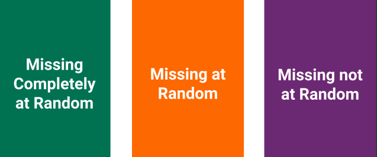

1. Missing Completely at Random (Perdido Completamente al azar).
2. Missing at Random (Perdido al azar).
3. Missing not at Random (Perdidos no al azar).

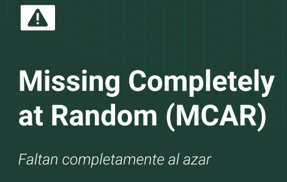

Para esta explicación decimos que nosotros podríamos tener una cámara o una herramienta que nos ayude a medir alguna cantidad.

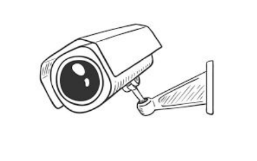

Nosotros tenemos nuestra herramienta y todo esta funcionando, pero parece que algún día va a fallar sin ninguna o alguna razón aparente

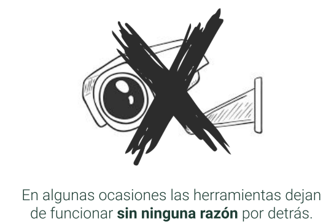

El hecho de que una herramienta falle sin ningún razón decimos que: *fallan al azar*

Y esto esta relacionado con los datos **Perdidos completamente al azar**, quiere decir que:

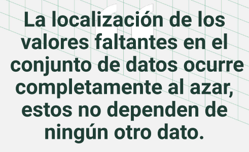

Después tenemos tenemos los siguientes datos

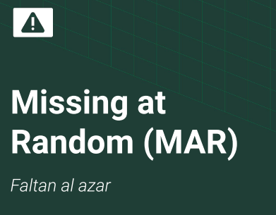

Datos perdidos al azar, siguiendo nuestro ejemplo de la cámara o herramienta, decimos que las herramientas necesitan **mantenimiento para asegurar su funcionamiento**, es decir que sea constante y confiable. Por eso nosotros cada determinado tiempo damos mantenimiento a la herramienta y lo hemos determinado según sea la conveniencia, por lo que en el tiempo en el que se realice la tarea no hay una recolección de datos.

Entonces al momento de recolectar la información en nuestro set de datos, vemos que en el periodo en que hemos realizado el mantenimiento nos faltan datos y en este caso esa perdida esta asociada a algo que sabemos que sucede **la fecha de reparación o mantenimiento de la herramienta**. Esta es la definición de la Perdida de al azar.

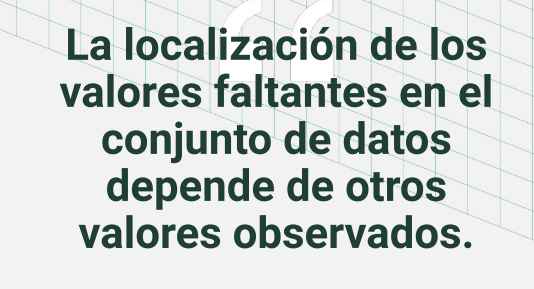

En este caso los valores observados son la fecha en la realizamos el mantenimiento.

Finalmente tenemos

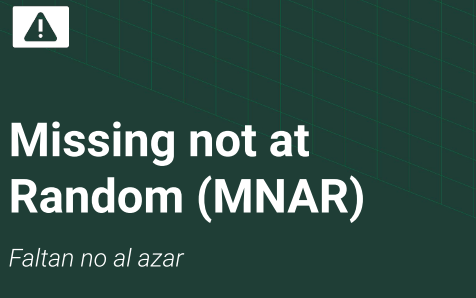

Estos datos son muy peculiares y muy difíciles de identificar.

Siguiendo el ejemplo de la herramienta de medición, algunas vemos no sabremos que hay falta de datos porque no podemos observarlos y se debe al hecho de que las herramientas tienen limites y al tratar de cuantificar cosas fuera del rango de trabajo se generan valores faltantes, pero son tan especiales que no podemos realizar un seguimiento de ellos.

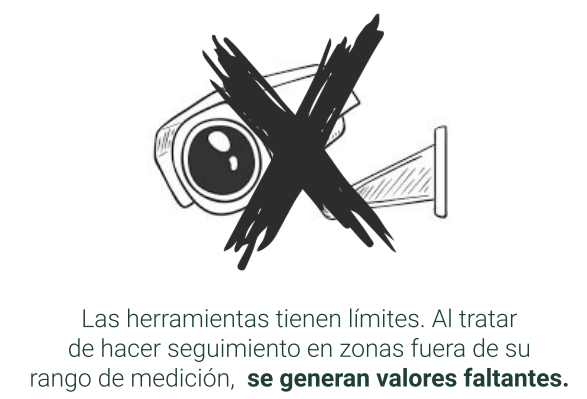

Es decir no sabemos que nos faltan estos datos, es decir esta es la definición de los datos **Perdidos no al azar**

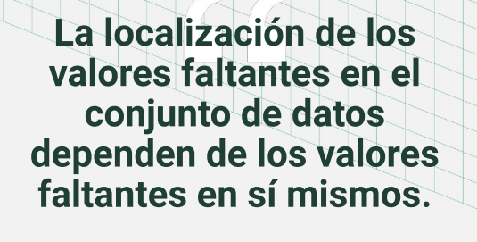

Otro ejemplo:

Tenemos una bascula en la cual estamos tratando de pesar algo:

- Si el peso es demasiado pequeño, tal vez los medidores ni lo detecten.
- Si el peso es demasiado grande, el rango de medición no es suficiente y esta fuera del alcance del aparato.

Ahora que conocemos los tipos de mecanismos sobre los cuales pueden actuar los valores faltantes es muy probable que nos preguntemos lo siguiente:

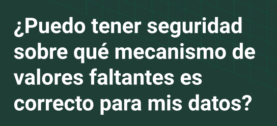

No, no podemos tener la seguridad de que los datos faltantes son provenientes de este tipo de mecanismo. No obstante a traves del análisis y exploración, conocimiento dirigido del tema podemos hacer suposiciones razonables y llegar a la conclusion de que lo mas probable que los datos faltantes sean al azar, no al azar o que sean completamente perdidos al azar.

Todo este tipo de análisis y exploración puede hacer que concluyamos o lleguemos a una suposición buena y conforme a estas suposiciones decidiremos que hacer con nuestros datos.